# Tiesinė regresija

Milda Zarankaite

Sunday, March 13, 2016

# Tiesinė regresija

Statistikos ir ekonomikos tyrimuose neretai siekiama ištirti reiškinių priklausomybę, pavyzdžiui:  
* Kaip parduodamų ledų kiekis priklauso nuo oro temperatūros?  
* Ar bakalauro darbo įvertinimas turi įtakos darbo užmokesčiui?  
* …

Šias priklausomybes galima nustatyti regresinės analizės pagalba. Sudaromas regresinis modelis - statistinis modelis, padedantis nustatyti vieno kintamojo priklausomybę nuo kito. Regresija yra tiesinė, kai vienas kintamasis nuo kito priklauso tiesiškai. Tarkime, kad mūsų duomenis sudaro $n$ porų : ${(x_i,y_i), i=1,..,k}$. Bendriausias regresijos modelis, siejantis kiekvieną $x$ ir $y$:

$$Y={\alpha}+{\beta}X+{\epsilon},$$

kur $Y=(y_1, y_2,.., y_k)^T$ - priklausomo kintamasojo reikšmių vektorius, $^T$ -transponuota,  
$X=(x_1,x_2,...,x_k)^T$ - nepriklausomo kintamamojo reikšmių vektorius,  
${\alpha}$ ir ${\beta}$ - konstantos.  
${\epsilon}=(e_1,e_2,..,e_k)$ - atsitiktinių paklaidų vektorius.

Regresijos tikslas yra surasti lygtį $\hat{Y}=\hat{\alpha}+\hat{\beta}X+\hat{\epsilon}$, kuri “geriausiai” atitiktų turimus duomenis. Tiksliausia lygtis randama Mažiausių kvadratų metodu: išbrėžiama tiesė, kuri minimizuoja paklaidų kvadratų sumą nuo tiesinio regresinio modelio. ${\alpha}$ tampa konstanta, o ${\beta}$ - krypties koeficientu.

**Tiesinė daugialypė regresija** tiriama, kai vieną priklausomąjį kintamąjį $Y=(y_1, y_2,.., y_k)^T$ sieja tiesinė priklausomybė su $n$ nepriklausomų kintamųjų $X=(X_1,X_2,..,X_n)^T$. Tuomet tiesinė daugialypė regresija išreiškiama:

$$Y={\alpha}+{\beta}_1X_1+{\beta}_2X_2+...+{\beta}_nX_n+e={\alpha}+\vec{\beta}X+{\epsilon}$$
,

čia $X$ nepriklausomų kintamųjų matrica, kurią sudaro:  
$\vec{X_1}=(x_{11},x_{12},...,x_{1n})$,  
$\vec{X_2}=(x_{21},x_{22},...,x_{2n})$,  
… ,  
$\vec{X_k}=(x_{k1},x_{k2},...,x_{kn})$;  
${\alpha}$, $\vec{\beta}=({\beta}_1,{\beta}_2,...,{\beta}_k)^T$ yra nežinomos konstantos,  
${\epsilon}$ - atsitiktinė paklaida.

Tikslas - **regresijos tiesės lygtis**, t.y. rasti tokius ${\alpha}$ ir ${\beta}$ įverčius $\hat{\alpha}$, $\hat{\beta}$, kad

$$\hat{Y}=\hat{\alpha}+\hat{\beta}_1X_1+\hat{\beta}_2X_2+...+\hat{\beta}_kX_n+\hat{\epsilon}$$
,

paklaidos $\hat{\epsilon}=(e_1,e_2,...,e_k)$ būtų mažiausios. $\hat{\epsilon}=Y-\hat{Y}=Y-(\hat{\alpha}+\hat{\beta}X)$ ,  
vadinamas atsitiktine liekamąja paklaida, kiekvienam $i=1,2,…,k$.

Įvertinimas daromas naudojantis [mažiausių kvadratų metodu](https://en.wikipedia.org/wiki/Least_squares).

Viena pagrindinė tiesinių regresinių modelių nauda - priklausomojo kintamojo prognozė. T.y. atradę tiesinę priklausomybę, galime nustatyti, kaip keisis $Y$ reikšmė, pakeitus nepriklausomąjį kintamąjį $X$.

Šiame įraše pateikiamas pavyzdys kaip atliekama išsami tiesinė regresija naudojantis statistine programa R.

### Pavyzdys

Turimi duomenys - nekilnojamojo turto (gyvenamųjų butų) kainos ir keletas jų charakteristikų. Tikslas - sumodeliuoti tiesinę regresiją, kuri padėtų prekybos agentams geriau suprasti kokią įtaką skirtingos charakteristikos daro galutinei būsto kainai.

#### 1.Duomenys:

**1.1.** Susipažįstama su duomenimis:

```r
#instaliuojamos analizei reikalingos bibliotekos
library(car)
library(knitr)
```

[output not shown]

Pateikiamos charakteristikos: plotas, aukštas, garsoIzoliacija, silmosLaidumas, atstumasIkiPrekybosCentro. Svarbu patikrinti nepriklausomų kintamųjų, šiuo atveju - charakteristikų, koreliaciją. Koreliacijos atveju, tie patys kintamieji, turi labai panašią įtaką kainai. Tad pirmiausia stebime kaip atrodo turimi duomenys, ar nėra akivaizdžių koreliacijų:

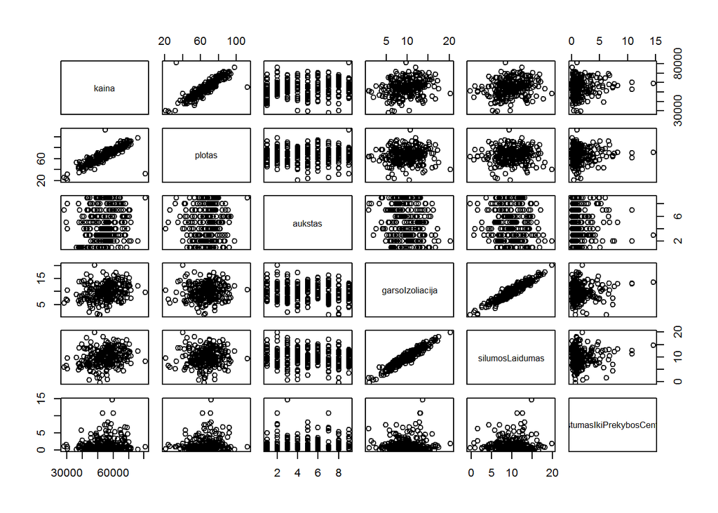

**1.2.** Pastebima, kad 2 rodikliai - garsoIzoliacija ir silumosLaidumas - tiesiškai susiję, todėl tikrinama galima duomenų **koreliacija**.

```r
print(cor(datafull), digits = 3)
```

```
##                            kaina plotas aukstas garsoIzoliacija
## kaina                     1.0000 0.8567  0.1209          0.2517
## plotas                    0.8567 1.0000  0.0443          0.0635
## aukstas                   0.1209 0.0443  1.0000         -0.1377
## garsoIzoliacija           0.2517 0.0635 -0.1377          1.0000
## silumosLaidumas           0.2390 0.0585 -0.1257          0.9536
## atstumasIkiPrekybosCentro 0.0899 0.0732 -0.0115          0.0338
##                           silumosLaidumas atstumasIkiPrekybosCentro
## kaina                              0.2390                    0.0899
## plotas                             0.0585                    0.0732
## aukstas                           -0.1257                   -0.0115
## garsoIzoliacija                    0.9536                    0.0338
## silumosLaidumas                    1.0000                    0.0336
## atstumasIkiPrekybosCentro          0.0336                    1.0000
```

Kadangi koreliacijos koeficientas tarp aptartų rodiklių labai didelis (arti 1) - rodikliai labai susiję, t.y. abu apibūdina buto izoliaciją. Tai reikškia, kad koeficientų įverčiai tikriausiai bus paslinkti. Siekiant panaikinti šią problemą reikia arba panaikinti vieną iš kintamųjų arba juos kažkaip sujungti.  
Sujungti (vienas iš būdų - skaičiuoti vidurkį) nepasirenkama, nes nenustatyta ar abiejų koeficienų duomenis apibūdina tie patys matavimo vienetai. Išvada: ištrinami garsoIzoliacijos duomenys. SilumosLaidumas yra svarbesnis, daro įtaką gyventojų išlaidoms, t.y mokesčiams už šildymą.

```r
datafull$garsoIzoliacija<-NULL
```

**1.3.** Tikrinamos **išskirtys**  
Viena iš priežasčių, kodėl kuriami modeliai nėra tikslūs - duomenyse yra išskirčių. Jos iškreipia pagrindines duomenų charakteristikas, tokias kaip vidurkis, dispersija. Siekiant sukurti kuo tikslesnę regresiją, išskirtis rekomenduojama pašalinti.  
Sukuriamas modelis $modIsskirtims$ ir braižomas kvantilių grafikas [Q-Q plot](http://www.r-bloggers.com/exploratory-data-analysis-quantile-quantile-plots-for-new-yorks-ozone-pollution-data/), kuris parodo reikšmių pasiskirstymą:

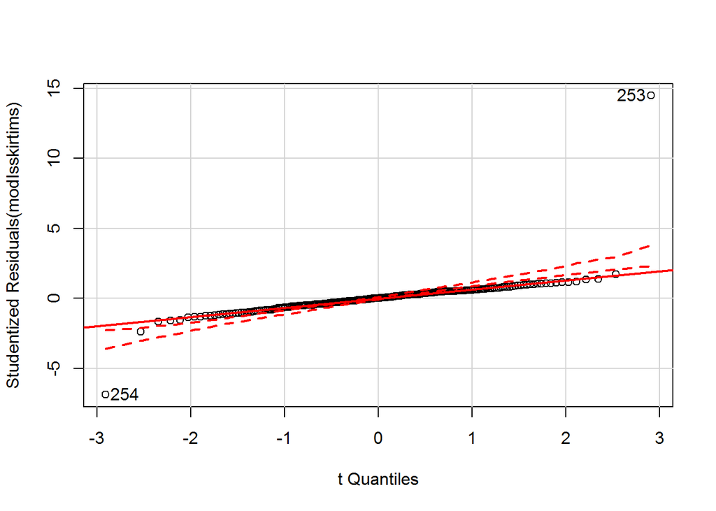

```
## 254 253
##   1 254
```

```r
modIsskirtims<-lm(kaina~+plotas+aukstas+silumosLaidumas+atstumasIkiPrekybosCentro, datafull)
qqPlot(modIsskirtims, id.n=2)
```

Pastebima, kad duomenyse yra išskirčių, tad duomenys tikrinami pagal “outlierTest” diganostiką:

```r
outlierTest(modIsskirtims)
```

```
##      rstudent unadjusted p-value Bonferonni p
## 253 14.486648         7.1195e-35   1.8084e-32
## 254 -6.882738         4.7778e-11   1.2136e-08
```

Rezultatas: pagal Bonferonni p korekciją (p-value<0.05) - eilutėse 253 ir 254 stebimos išskirtys. Eilutes su duomenimis, kuriuose yra išskirtys - pašaliname. Sukuriami nauji duomenys pavadinimu “data”, kurie bus naudojami tolimesnei analizei.

```r
data<-datafull[-c(253,254),]
```

#### 2.Modelio kūrimas

**2.1.** Sukuriamas *tiesinis modelis* nuo visų turimų kintamųjų

```r
mod1<-lm(kaina~+plotas+aukstas+silumosLaidumas+atstumasIkiPrekybosCentro, data)
kable(summary(mod1)$coef, digits=3)
```

|  | Estimate | Std. Error | t value | Pr(>\|t\|) |
| --- | --- | --- | --- | --- |
| (Intercept) | 7966.669 | 977.862 | 8.147 | 0.000 |
| plotas | 599.371 | 12.130 | 49.410 | 0.000 |
| aukstas | 318.658 | 63.493 | 5.019 | 0.000 |
| silumosLaidumas | 527.454 | 47.522 | 11.099 | 0.000 |
| atstumasIkiPrekybosCentro | 85.454 | 81.381 | 1.050 | 0.295 |

Iš summary lentelėje pateiktos p-value galime teigti, kad koeficientas prie kintamojo “atstumasIkiPrekybosCentro” yra nereikšmingas (H0: b4=0 - priimame), todėl jis pašalinamas.

**2.2.** Atnaujinamas mod2 ir tikrinamas jo **kintamųjų reikšmingumas**

```r
mod2<-update(mod1, kaina~plotas+aukstas+silumosLaidumas)
kable(summary(mod2)$coef, digits=3)
```

|  | Estimate | Std. Error | t value | Pr(>\|t\|) |
| --- | --- | --- | --- | --- |
| (Intercept) | 8035.795 | 975.845 | 8.235 | 0 |
| plotas | 600.334 | 12.098 | 49.622 | 0 |
| aukstas | 318.225 | 63.504 | 5.011 | 0 |
| silumosLaidumas | 528.818 | 47.514 | 11.130 | 0 |

Kadangi likę įverčiai reikšmingi - tikriname modelio tikslumą. Toliau tikrinamos prielaidos, kurias turi atitikti “geras” modelis.

#### 3.Modelio patikimumo parametrai

**3.1.** “R-Squared”:

```r
(summary(mod2))$r.squared
```

```
## [1] 0.915869
```

$R^2$ yra statistinis matas, kuris parodo, kaip duomenys yra “arti” regresinės tiesės. $R^2$ reikšmė yra intervale [0,1], tad kuo matas arčiau 1 - tuo regresinė tiesė labiau prisitaikiusi prie duomenų. Be to, šis rodiklis taip pat labai naudingas, kai siekiama palyginti keletą modelių.

**3.2.**[Multikolinearumo tikrinimas](http://www.statisticssolutions.com/multicollinearity/)  
Statistikoje multikolinearumas yra fenomenas, kuris nurodo, kad regresijoje 2 ar daugiau kintamųjų yra koreliuoti. Šios problemos egzistavimą tikriname naudojant Various Inflation Factor:

```r
vif(mod2)
```

```
##          plotas         aukstas silumosLaidumas
##        1.005730        1.017733        1.019520
```

Multikolinearumo problemos nėra. Taip teigiama, nes egzistuojančią vidinę koreliaciją parodo koeficientai, kurių reikšmė yra daugiau nei 10 (VIF sąlyga).

- Jeigu modelio kintamieji turi multikolinearumo problemą, galimos regresijos pasekmės:
1. sulaukiame, kad kintamieji yra nereikšmingi, nors žinome, kad jų bendras poveikis tikrai nėra nulinis;
2. koreliuotų kintamųjų įgyti koeficientai - priešingų reikšmių, t.y. jie vienas kitą kompensuoja. Todėl prarandama aiški interpretacija.

**3.3.** [Homoskedastiškumo tikrinimas](http://www.statisticssolutions.com/homoscedasticity/)  
Homoskedastiškumas parodo, kad regresijos atsitiktinės paklaidos yra visur vienodos. Išbrėžiamos sukurto modelio paklaidos:

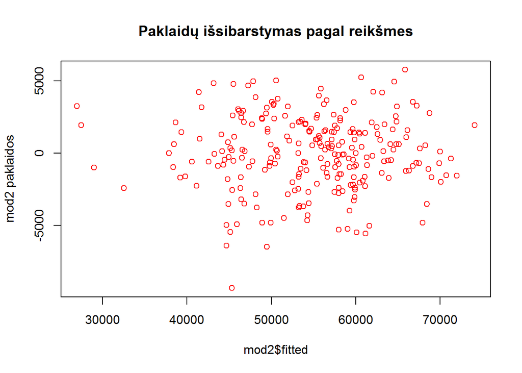

Kaip matome, paklaidos pasiskirsčiusios pagal vidurkį 0, daugiausia intervale (-5000,5000). Todėl spėjama, kad modelis - homoskedastiškas. Tai dar tikrinama pagal Breuch-Pagan testą

```r
ncvTest(mod2)
```

```
## Non-constant Variance Score Test
## Variance formula: ~ fitted.values
## Chisquare = 3.218568    Df = 1     p = 0.0728073
```

Kadangi p>0.05, vadinasi, priimame testo H0 hipotezę, kuri teigia, kad modelis homoskedastiškas - visų stebėjimų paklaidų dispersija yra konstanta.

- Jei homoskedastiškumas nėra tenkinamas, tai formaliai didelės blogybės nėra - įverčiai ir toliau liktų nepaslinkti ir suderinti. Visgi reiktų būti atidiem ir papildomai pasvarstyti tris svarbius niuansus:
1. Nehomogeniškumas gali indikuoti modelio neadekvatumą. Pvz. gal liko nepastebėta netiesinė sąveiką? O gal liko didelių išskirčių?
2. Statistinio reikšmingumo tikrinimui naudojama kovariacijų matrica gali būti neteisinga.
3. Nors įverčiai nepaslinkti, bet dabar negalime teigti, kad jie yra efektyvūs - tokiu atveju gali būti ir geresnių vertinimo būdų.

**3.4.** Tikrinamas *liekanų normalumas*

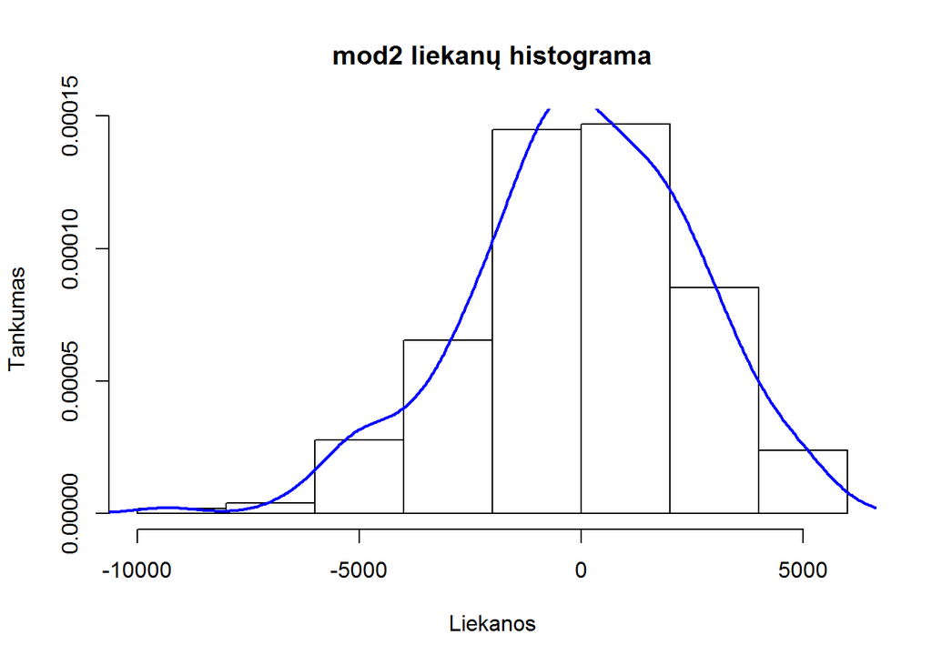

Mėlyna linija šioje histogramoje parodo liekanų tankumą. Ji primena varpo formą, tad spėjama, kad liekanos pasiskirsčiusios normaliai. Prielaida dar tikrinama Shapiro testu:

```r
shapiro.test(mod2$res)
```

```
##
##  Shapiro-Wilk normality test
##
## data:  mod2$res
## W = 0.9898, p-value = 0.07272
```

Pagal shapiro.test p-value>0.05 priimame H0: liekanų paklaidos yra normalios.

- Liekanų normalumą svarbu patikrinti tam, kad nustatytume, ar iš duomenų ištraukta visa naudinga informacija ir panaudota modelyje. Pavyzdžiui, ar atrasta duomenų tendencija įvertinta modelyje. Jeigu atsakymas teigiamas, paklaidos yra baltasis triukšmas (išsidėsčiusios nepriklausomai ir jų vidurkis yra 0):

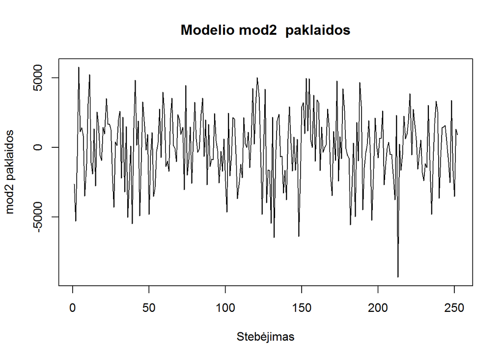

```r
plot(residuals(mod2), type="l", main="Modelio mod2  paklaidos", ylab="mod2 paklaidos", xlab="Stebėjimas")
```

Jeigu sąlyga netenkinama - modelis dar nėra pakankamai “geras”, tad verta pasvarstyti jo tobulinimą.

**3.5.** Tikinama [liekanų autokoreliacija](https://onlinecourses.science.psu.edu/stat501/node/359)  
Geram modeliui taip pat svarbu, kad liekanos nebūtų susiję tarpusavyje. Tai tikrina Durbin-Watson testas:

```r
durbinWatsonTest(mod2)
```

```
##  lag Autocorrelation D-W Statistic p-value
##    1      0.05475525      1.885685   0.368
##  Alternative hypothesis: rho != 0
```

Kadangi testo p-value>0.05, H0: nėra koreliacijos tarp liekanų, priimame.

- Jeigu testo nulinė hipotezė atmetama - įverčiai vis dar yra nepaslinkti ir suderinti, tačiau tampa nebeefektyvūs. Taip yra todėl, kad įverčių variacija - paslinkta ir nesuderinta. ?? Pagrindinė liekanų autokoreliacijos problema - netikslumai prognozuojant.

Vadinasi, kadangi modelis atitinka šiuos kriterijus, galime teigti, kad teisingas modelis $kaina~+plotas+aukstas+silumosLaidumas$. Atitinkamai įverčiai parodo kaip pakitus vienam vienetui iš šių charakteristikų, pakinta kaina: $kaina=8035.8 + 600.33*plotas+3.18.23*aukstas+528.82*silumosLaidumas+e$  
Interpretacija: 1 kv.m padidėjimas padidina kainą 600,33eurais, kiekvienas papildomas aukštas kainą padidina 318,23 eurais, 1 vnt. šilumos laidumo koeficiento padidėjimas padidina kainą 528,82 eurais. Laisvasis narys - 8035,80 eurai gali būti papildomas išlaidos pvz.:notaro paslaugos, buto lokacija, viešojo transporto prieinamumas ir pan.

### Trumpai apie modelio “gerinimą”

Sudarytas modelis mod2 - geras, ir tinka pradedantiems mokytis regresinės analizės. Tačiau, duomenys neretai gali būti ranginiai, kas pastebima ir atidžiau išanalizavus mūsų turimus duomenis. Galime pastebėti, kad kintamasis $aukstas$ - yra ranginis kintamasis. Tai galime matyti iš liekanų boxplot grafiko:

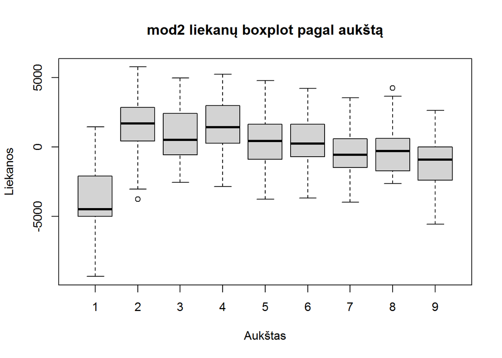

```r
boxplot(mod2$residuals ~ data$aukstas, col = "lightgray", main="mod2 liekanų boxplot pagal aukštą", ylab="Liekanos", xlab="Aukštas")
```

Iš grafiko matome, kad pirmo aukšto kaina neatitinka regresinės tiesės lygties, t.y. paklaidos neigiamos, jų vidurkis nėra lygus 0. Tai reiškia, kad pirmo aukšto kainos yra gerokai mažesnės ir neatitinka sukurto modelio. Siekiant į tai atsižvelgti, galima kurti modelį, kuriame išskiriamas pirmas aukštas:

```r
aukstas1<-data$aukstas==1
mod3<-lm(kaina~plotas +aukstas1+silumosLaidumas,data=data)
kable(summary(mod3)$coef,digits=2)
```

|  | Estimate | Std. Error | t value | Pr(>\|t\|) |
| --- | --- | --- | --- | --- |
| (Intercept) | 10235.63 | 748.04 | 13.68 | 0 |
| plotas | 598.84 | 9.83 | 60.94 | 0 |
| aukstas1TRUE | -5440.16 | 422.84 | -12.87 | 0 |
| silumosLaidumas | 531.42 | 38.39 | 13.84 | 0 |

Gautame modelyje “aukstas1TRUE” yra kintamasis, kuris galioja tik tuo atveju, jei pasitinkto buvo aukštas yra pirmas. Kitu atveju - jis modelyje įgyja reikšmę 0. Matoma, kad visi kintamieji reikšmingi. Tikrinama ar šis mod3 yra tikslesnis pagal R^2 ir AIC kriterijus:

```r
aic<-c(AIC(mod2), AIC(mod3))
r.sq<-c((summary(mod2))$r.squared, (summary(mod3))$r.squared)
pav<-c("mod2", "mod3")
tab<-data.frame(pav,aic,r.sq)
tab
```

```
##    pav      aic      r.sq
## 1 mod2 4673.994 0.9158690
## 2 mod3 4569.454 0.9444361
```

- Naudoti informacijos šaltiniai:  
  R. Lapinskas. [Practical Econometrics I. Regression Models (Lecture Notes)](http://www.statistika.mif.vu.lt/wp-content/uploads/2014/05/PE.I-2013-CompLabs.2013.12.17_t.pdf), 2013, Vilnius.